# Look into satellite data

Maite

14 12 2021

# Retrieve logger locations

# Data preparation:

d=type of Landsat data (1=bt,2=sr)

## SR

lsr_landsat_8_c1 lsr_landsat_etm_c1 [Info from USGS on scaling](https://www.usgs.gov/faqs/how-do-i-use-scale-factor-landsat-level-2-science-products)

Scale factor for C1 surface reflectance is 0.0001, Fill value is -9999 and valid range 0 to 10000.

Scale factor was applied, but valid range not applied

Landsat 8 acquisition time comes in GMT. iBut data was gathered in NZDT, but comes in the geopackage in CET/CEST… ???

bands 2 (b), 3(g), 4(r), 5(NIR), 6 (SWIR1), 7 (SWIR2), 10(thermal)

# iButton - RH

## iButton Surface Reflectance vs. RH all sites together

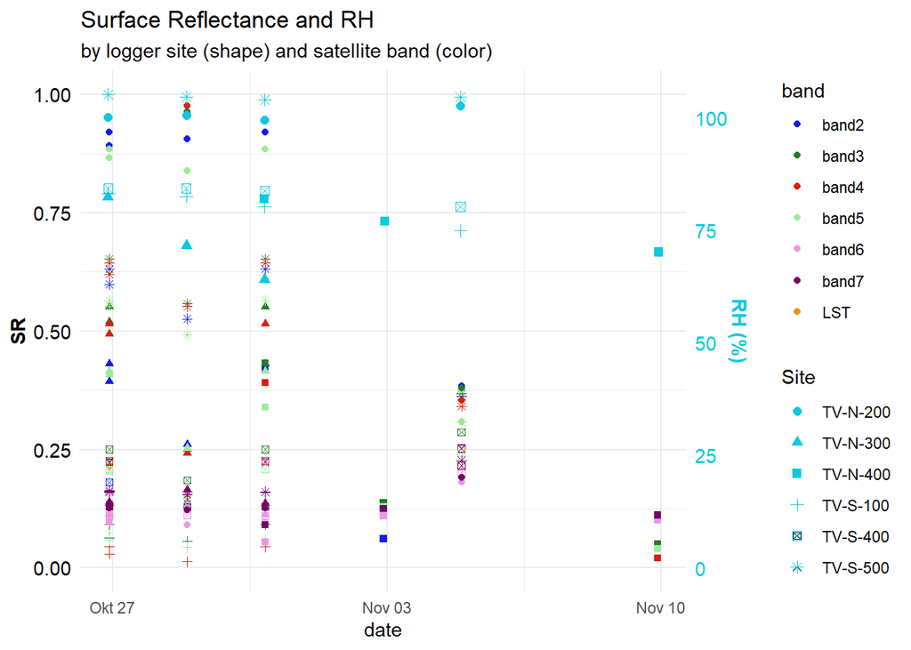

## iButton LST vs. RH all sites together

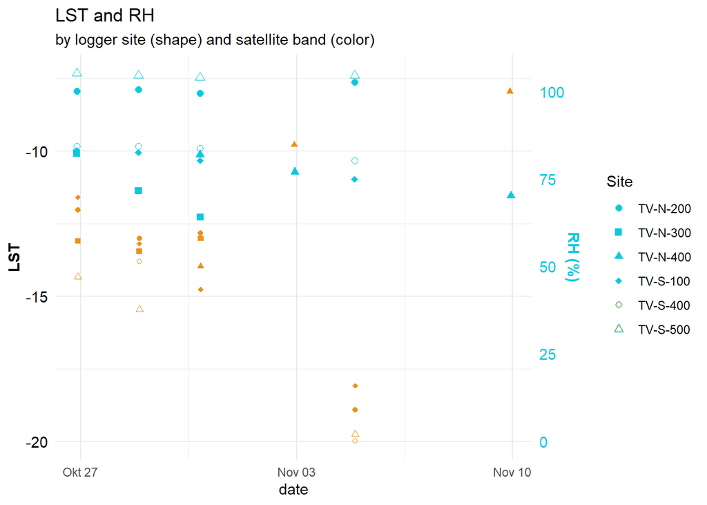

## iButton SR and LST vs. RH figure per site

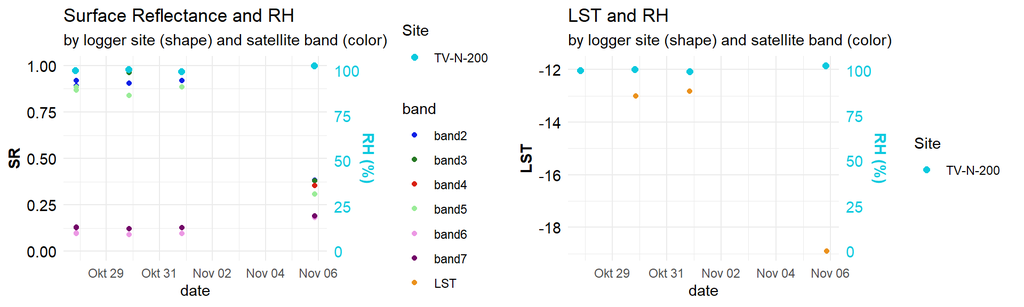

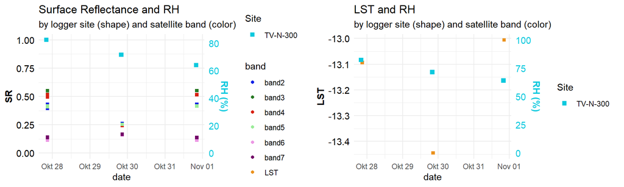

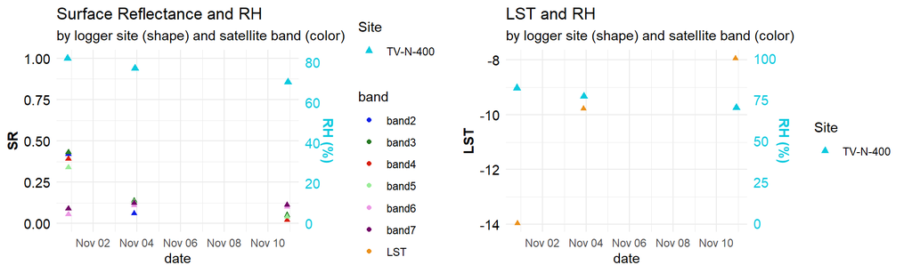

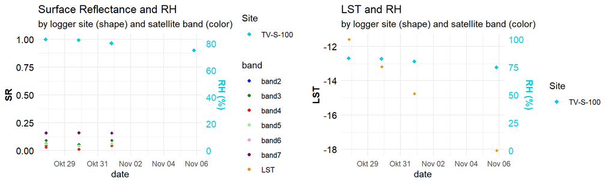

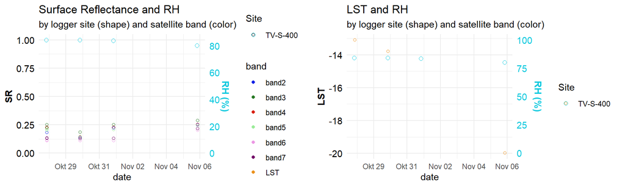

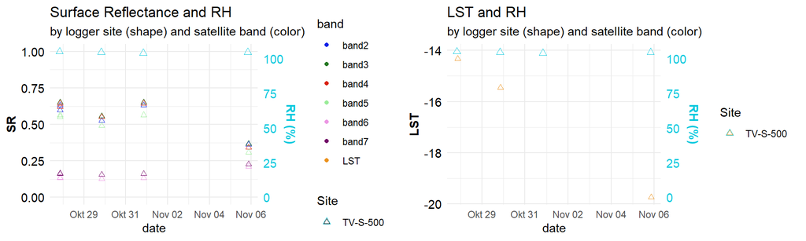

# AWSS - SMC

## AWSS Surface Reflectance vs. SMC all sites together

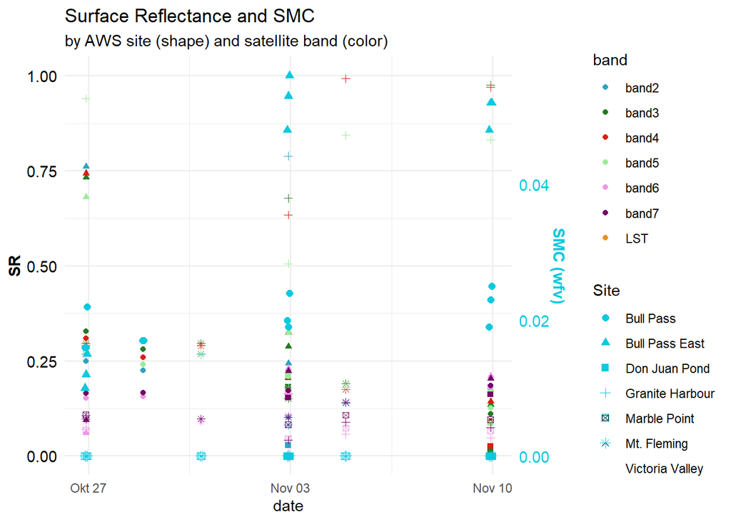

## AWSS LST vs. SMC all sites together

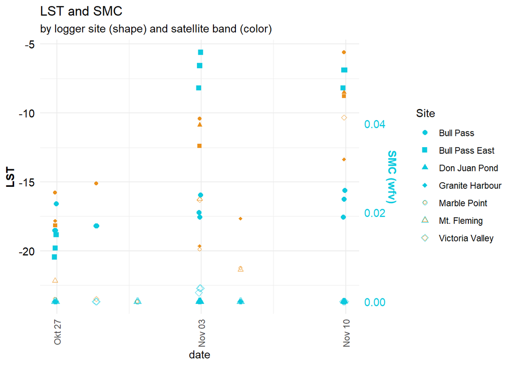

## AWSS SR and LST vs. SMC figure per site

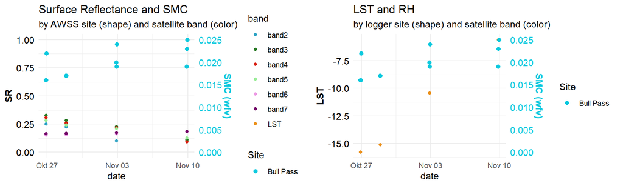

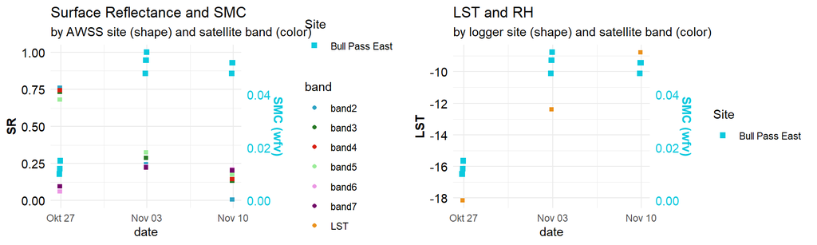

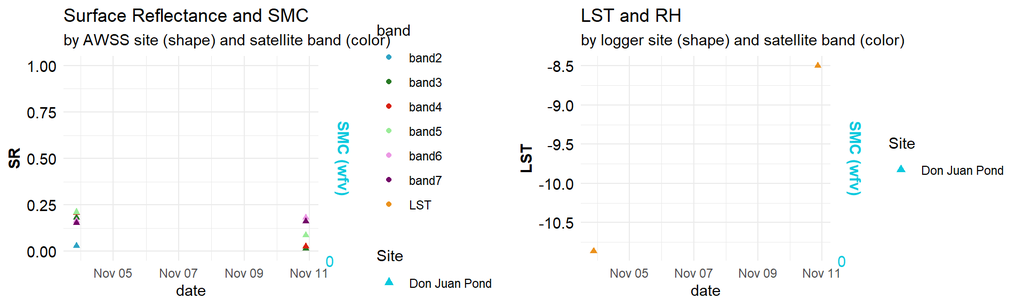

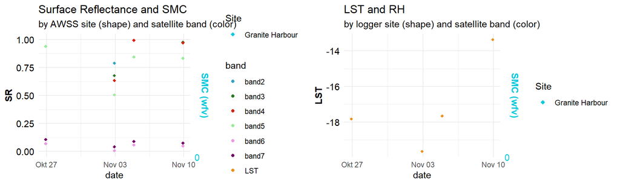

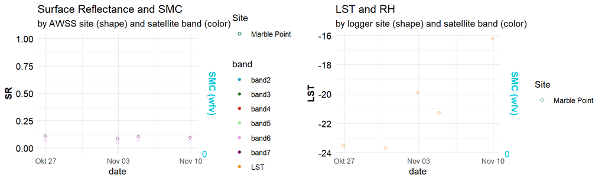

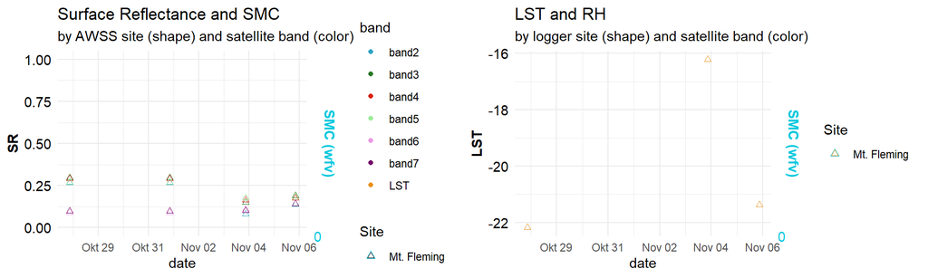

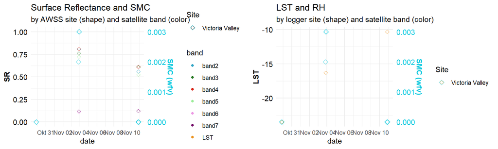

There might be something about the relation between reflectance in the visible light and SWIR reflectance.. it seems like always when the moisture (RH or SMC) is relatively high, SWIR remains low, while VIS is relatively high.. When VIS reflectance is pretty high, SMC is low. This is visible also in the following corrplot: rgb (bands 4,3,2) and nir (5) all correlate with SMC around r=-0.35 to r=-0.4, while SWIR bands 6 and 7 are positively correlated with r=0.77 and 0.83: For SMC it seems useful to try a VIS/SWIR index. SWIR band 6 seems best for exploiting the relation to VIS (measured reflectance was usually a bit lower than 7), especially with the green band 3, there is much negative correlation (-0.75).

# Correlations AWSS and SMC

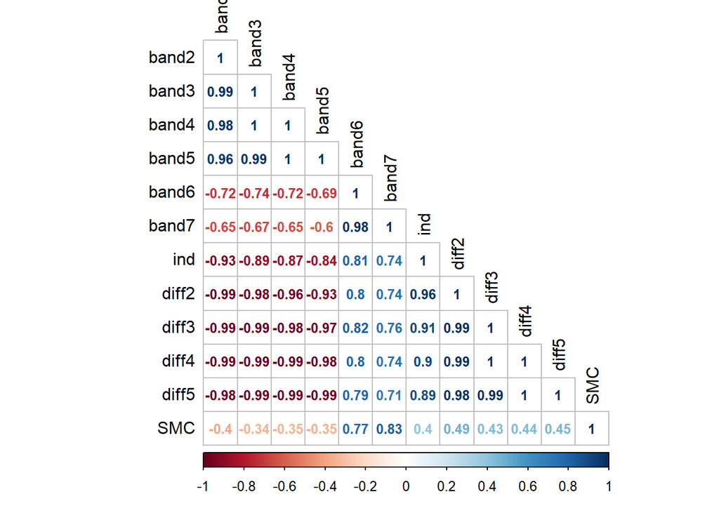

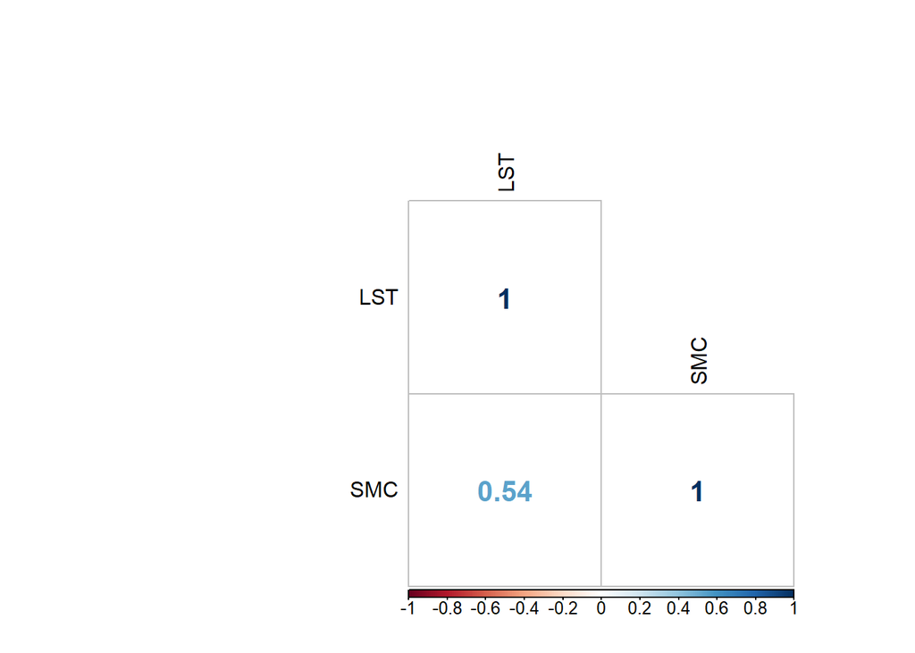

For RH and the iButtons, the relation seems to be the opposite, bands 2:5 are quite highly positively correlated with Rh, the SWIR bands not really, though.

# Correlations iButtons and RH

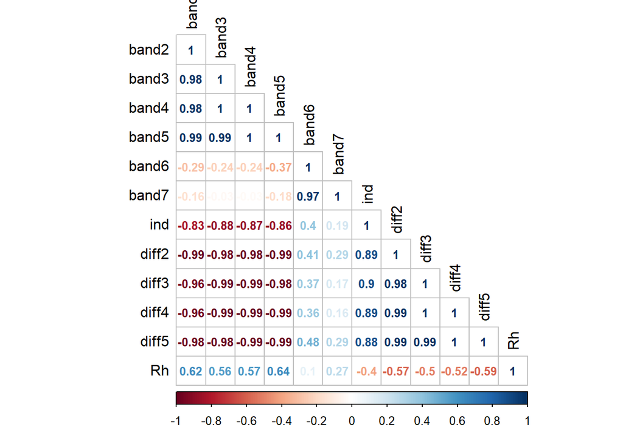

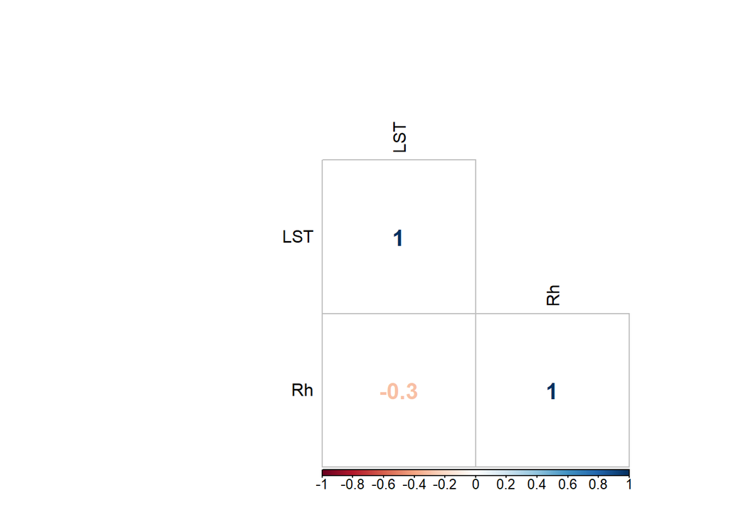